# The simplest use of *functClust*

Benoît Jaillard

2020-11-30

## The computational function *fclust*

The package *functClust* contains four main functions, *fclust*, *fclust_plot*, *fclust_write* and *fclust_read* (see vignette **Overview of functClust**).

The input of *fclust* is recorded in a *data.frame* such as described in vignette **a.Overview_of_functClust**. The colnames should included: assemblage identity (“Plot” in *CedarCreek.2004.2006.dat*); a matrix of component occurrence (from *“Achmi”* until *“Sornu”* in *CedarCreek.2004.2006.dat*); and at least one observed performance (*“y2004”*, *“y2005”* and *“y2006”* in *CedarCreek.2004.2006.dat*). Each assemblage is filled on a line.

For running, the function *fclust* needs also to know the number *nbElt* of components belonging to the interactive system in consideration. All other options are filled by default. The possibilities offered by the options are presented in the vignette **The options of fclust**.

```r
library(functClust)
nbElt <- 16
dat.2004 <- CedarCreek.2004.2006.dat[ , c(1, 1 + 1:nbElt, 1 + nbElt + 1)]
res <- fclust(dat.2004, nbElt)
```

In previous code, we select in *dat.2004* : *(i)* the first column of file *CedarCreek.2004.2006.dat*, that contains “Plot”, *i.e.* the identity of assemblages, *(ii)* the next *nbElt = 16* following columns, that contain the matrix of component occurrence, and *(iii)* only one assemblage performance, here the biomass *“y2004”* harvested in summer 2004.

## The plotting function *fclust_plot*

On another hand, the function *fclust_plot* plots only the main results obtained by a functional clustering when used without any option. Even *main* is “Title” by default.

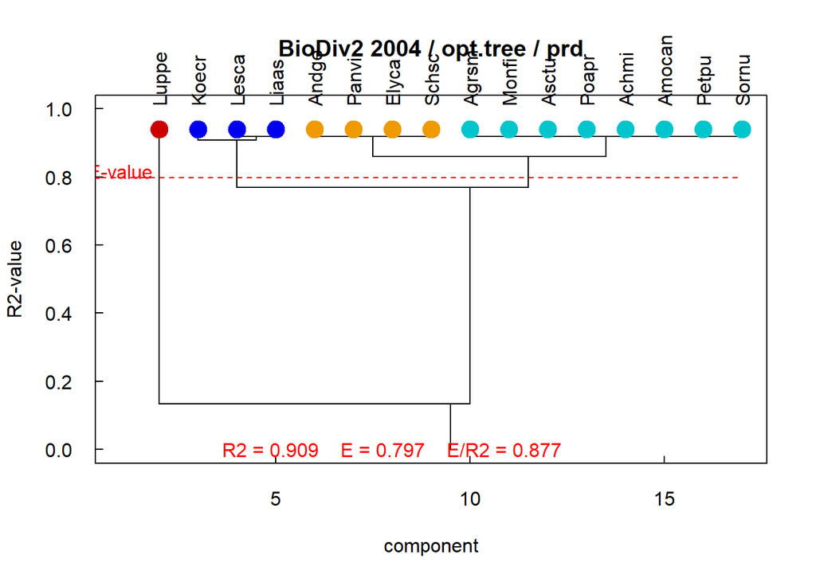

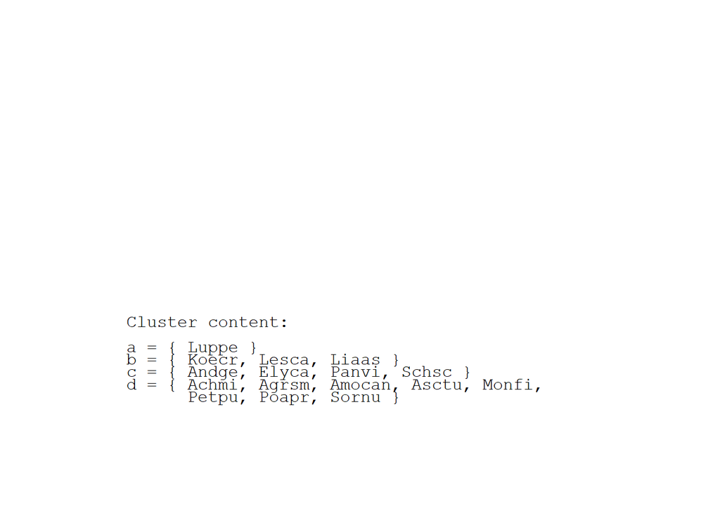

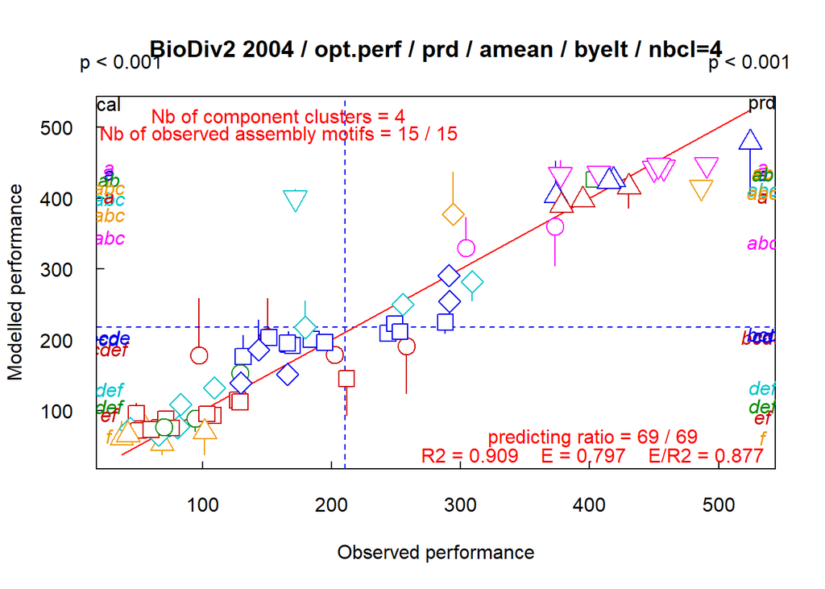

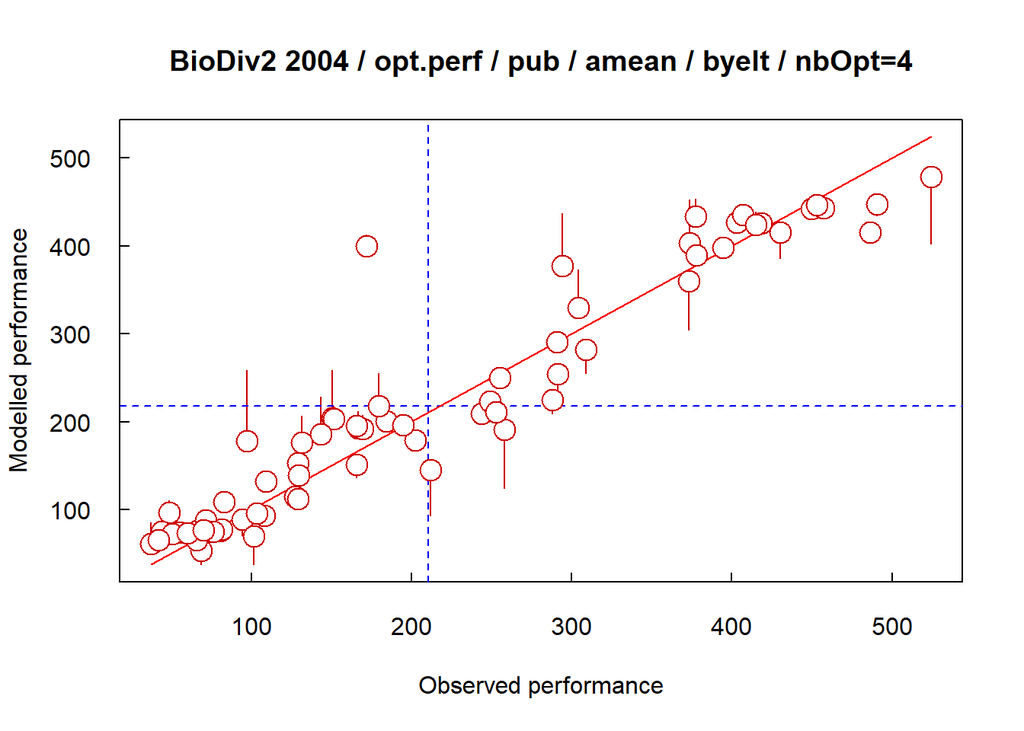

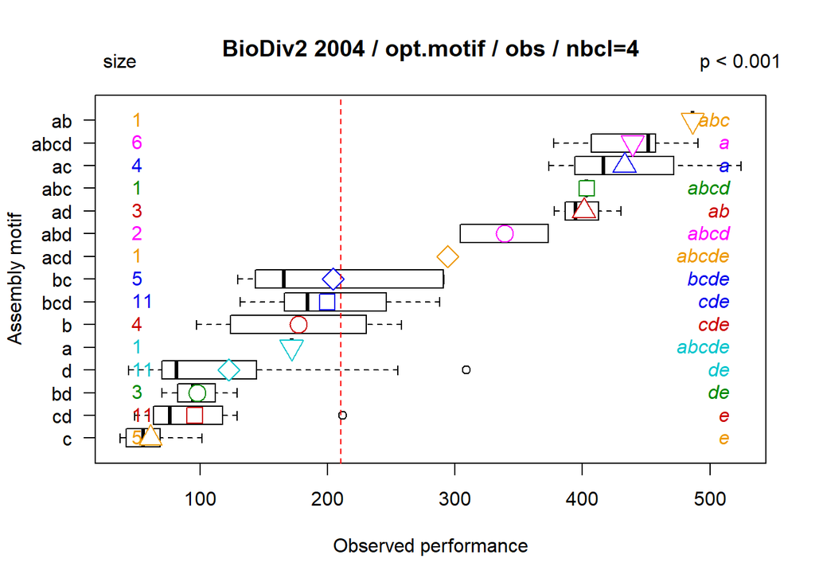

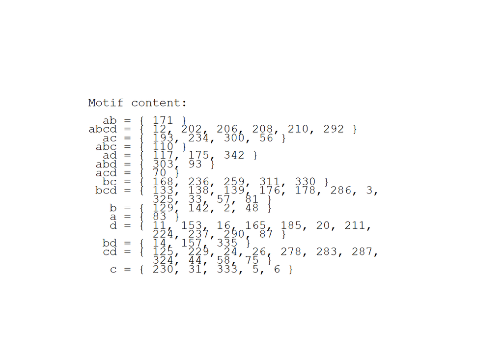

The simplest use of fclust_plot

```r
fclust_plot(res, main = "BioDiv2 2004")
```

Both the first graphs correspond to the validated, secondary tree pruned above the optimum number of component clusters. The left graph shows the hierarchical tree of component clustering, the right graph the names and contents of component clusters. The default options corresponding to the graph are included in the graph title (here “tree” and “prd”). The *x-axis* of tree is the system components. The *y-axis* of tree is the quality criterion of modelling, *i.e.* the coefficient of determination *R2* or efficiency *E*. On tree, each cluster is plotted with a different colour, and named by a letter. The leaves, *i.e.* the highest horizontal lines, are plotted at the level of the highest coefficient of determination of modelling (*R2-value*). Modelling efficiency (*E-value*) is indicated by a red dashed line. Values of *R2*, *E* and *E/R2* are indicated.

Both following graphs show the model goodness-of-fit. The default options corresponding to the graph are included in the graph title. Left and right graphs differ only by the used colours and symbols. On left graph, the performances of assemblages belonging to different assembly motifs are plotted with different symbols. The symbols correspond to performances predicted by the model (modelled performances), of which the goodness-of-fit is evaluated by tree coefficient of determination *R2*. The vertical lines correspond to performances independently predicted by cross-validation (independently predicted performances), of which the quality is evaluated by tree efficiency *E*. Global statistic are indicated (number of component clusters, number of assembly motifs, *R2*, *E* and the ratio *E/R2*). A variance analysis is indicated on detailled graph, on the left side for modelled performances, on the right side for performances predicted by cross-validation, using a defaut *pvalue = 0.05*.

On the right graph, all assemblages are plotted with only a colour and symbol. The graph is convenient for overview the model goodness-of-fit, but also for publication.

Finally, a boxplot of observed performances of assemblages belonging to different assembly motifs is plotted. Means are indicated with different symbols, of same symbol and colour as those used for different assembly motifs in previous detailled graph of model goodness-of-fit. The size (in number of assemblages) of each assembly motifs is indicated on the left side of the graph. The results of a variance analysis of observed performances by assembly motif is indicated on the right side of the graph. The last graph indicated the names of assemblages belonging to different assembly motifs.

## The output-input functions *fclust_write* and *fclust_read*

Both the functions *fclust_write* and *fclust_read* allow to record and reload the results obtained from a functional clustering. The results are recorded in CSV-format into 5 files that bring together elements of same kind. If *filename = “myRecord”*, the files are named: *“myRecord.options.csv”*, *“myRecord.vectors.csv”*, *“myRecord.trees.csv”*, *“myRecord.matrices.csv”* and *“myRecord.stats.csv”*.

```r
# fclust_write(res, filename = "myRecord")
# res <- fclust_read(filename = "myRecord")
```

## Note

Note that some computations are time-consuming. To facilitate the monitoring of the smooth running of the computations, informations are written on the Console and graphs are drawn on the Plots panel. The writting are enable or disable by the “verbose” option.

```r
getOption("verbose")
```

```
#> [1] FALSE
```

```r
# to follow the computations
options(verbose = TRUE)
# to deactivate the option
options(verbose = FALSE)
```